# Client segmentation

## Goal

The goal is to segment the customers of a bank using Unsupervised Machine Learning techniques, this is a segmentation carried out from the perspective of the financial services sector.

#### Dataset loading

```matlab
close all
clc
path = 'C:/Users/danie/Downloads/FINTECH/C) ML_LAB/LAB1/Zenti_BusinessCase1/BankClients.mat';
load(path)
```

### Data preparation

Extraction of the variables of interest, also dividing into:

- numerical;
- categorical (excluding the ID, which is not informative at this level).

We have to:

- encode categorical variables, so that they can be digestible by clustering algorithms, they are all trasformed in boolean variables by the dummyvar function.
- normalize in [0, 1] numerical variables using the rescale function.

```matlab
% Numerical
N = vartype('numeric');
Data = BankClients(:,2:end); % Exclude 1st col = ID

% Removing the gender and the family size
Data(:, "Gender") = [];
Data(:, "FamilySize") = [];

NumFeatures = Data(:,N); % subtable of numerical features
XNum = NumFeatures.Variables; % create a matrix
XNum = rescale(XNum); % normalize in [0, 1]

% Categorical
C = vartype('categorical');
CatFeatures = Data(:,C); % subtable of categorical features

% Encoding (ie create dummy variables)
%grp2idx create a vector of integer values from 1 up to the number K of distinct groups.
XCat = [];
for i = 1:size(CatFeatures, 2)
    XCat_i = dummyvar(grp2idx(CatFeatures{:,i}));
    XCat = [XCat XCat_i(:,1:end-1)]; % To use the dummy variables in a model, we must delete a column
end
```

Let's put all the features together in a matrix and start doing clustering analysis.

```matlab
X = [XCat XNum];
```

We also save the original dataset without the encoding for a later simpler cluster inspection.

```matlab
dati = Data;
```

### A short data exploration

#### Checking if there are highly correlater features

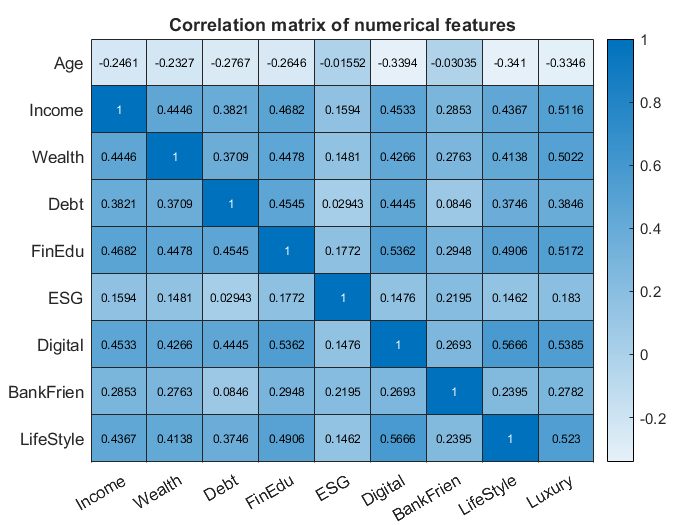

```matlab
figure
R = corrcoef(XNum); %computation of the correlation matric
yvalues = {'Age','Income','Wealth','Debt','FinEdu','ESG','Digital','BankFrien','LifeStyle','Luxury','Savings'};
xvalues = {'Age','Income','Wealth','Debt','FinEdu','ESG','Digital','BankFrien','LifeStyle','Luxury','Savings'};
h = heatmap(xvalues,yvalues, R );
h.Title = 'Correlation matrix of numerical features';
```

There are no highly correlated features.

Empirical distribution functions for the numerical features.

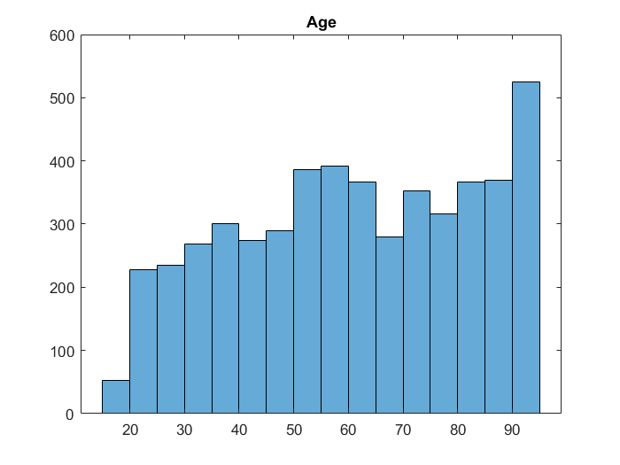

```matlab
histogram(Data.Age)
title('Age')
```

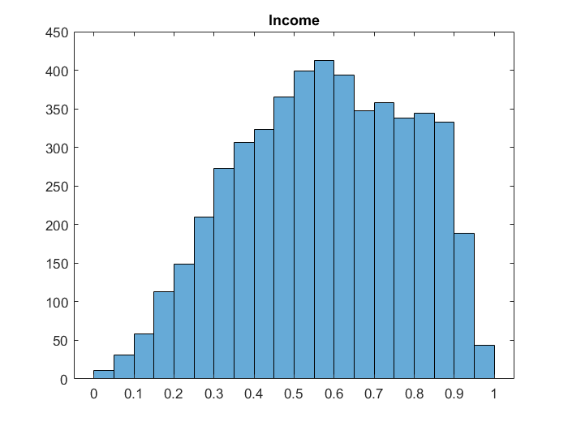

```matlab
histogram(Data.Income)
title("Income")
```

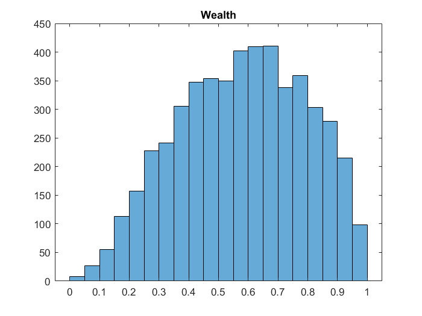

```matlab
histogram(Data.Wealth)
title("Wealth")
```

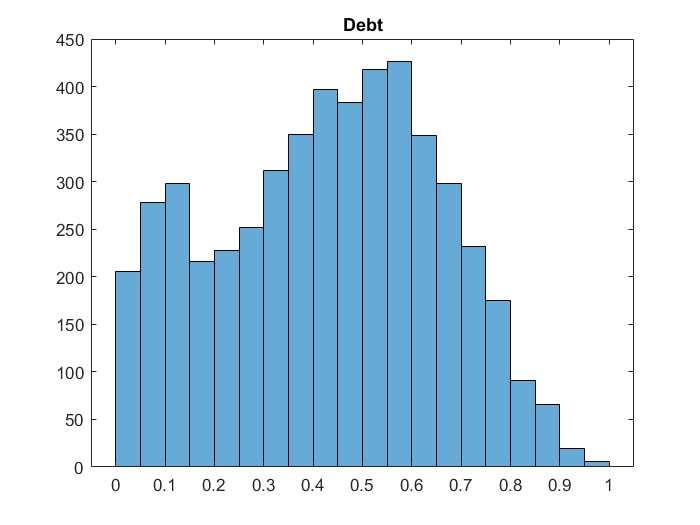

```matlab
histogram(Data.Debt)
title("Debt")
```

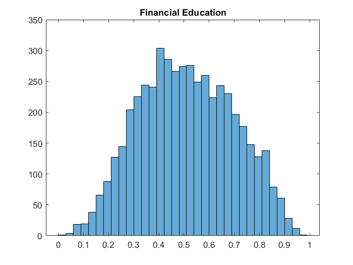

```matlab
histogram(Data.FinEdu)
title("Financial Education")
```

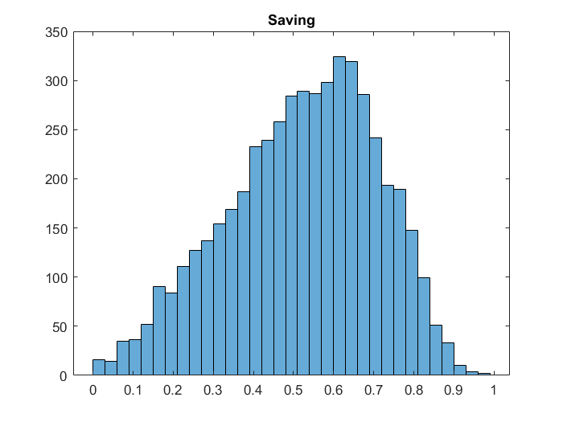

```matlab
histogram(Data.Saving)
title('Saving')
```

```matlab
tabulate(Data.Investments)
```

Value Count Percent 1 1314 26.28% 2 1496 29.92% 3 2190 43.80%

```matlab
tabulate(Data.Job)
```

Value Count Percent 1 609 12.18% 2 3284 65.68% 3 144 2.88% 4 107 2.14% 5 856 17.12%

For quick exploratory/model selection analysis, we use a random subsample of the original dataset to avoid long-lasting computational times.

```matlab
nSubSample = 1950;
rng('default') % for reproducibility
randRows = randperm(size(X, 1), nSubSample);
X = X(randRows', :);

%Dataset used later for cluster inspection
dati = dati(randRows', :);
```

## Unsupervised clustering with mixed categorical and continuous data

The sample space for categorical data is discrete, and doesn't have a natural origin, so an Euclidean distance (L2) function on such a space isn't really meaningful. So we need to introduce a new distance metric to measure the distance between our clients.

### Distance function

We use a created custom distance metric and function (MixDistanceL1):

- for the categorical variables we use the Hamming distance, which is the percentage of coordinates that differ;
- for the numerical features we use the L1 norm;
- we combine them using the relative weight of categorical/numerical variables.

We also try a variation of this new distance metric that we call MixDistanceL2, instead of the manhattan norm, this distance function use the Euclidean norm for the numerical features.

### Hierarchical Clustering

The goal is to identify the unknown groups between the clients, we don't know how many groups could exist. Units that belong to the same cluster are more similar than units belonging to different clusters so we will use the two distance metrics defined before to "identify" dissimilarity/similarity between clients and we look to find homogeneous subgroups among the clients who might be more receptive to a particular form of advertising, or more likely to purchase a particular product.

With hierarchical clustering we specify first the distance metric, then we compute a distance matrix. We also have to specify the linkage, which is the way we measure the dissimilarities between clusters.

Why hierarchical clustering? With hierarchical clustering we are referring to the fact that the clusters obtained by cutting the dendogram at a given height are necessary nested within the clusters obtained by cutting the dendogram at any greater height. So we are making a hierarchical structure assumption in our dataset; this idea of a hierarchical structure in our dataset comes from the fact that as humans we are all different, but with some common features, so we could guess a nested structure between groups.

### Some Data Exploration

Let's have a bird’s view of the characteristics of the dataset and the behaviour of different distance metrics.

Let's compare distance metrics using t-SNE: an algorithm for dimensionality reduction that is well-suited to visualizing high-dimensional data. The underlying idea is to embed high-dimensional points in low dimensions in a way that respects similarities between points to see natural clusters in the original high-dimensional data, using specific distance metrics.

We begin with 2-D t-SNE embedding.

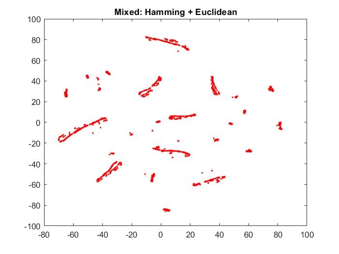

```matlab
rng('default') % for reproducibility 9clu
Y = tsne(X,'Algorithm','exact','Distance', @MixDistanceL1);
gscatter(Y(:,1),Y(:,2))
title('Mixed: Hamming + Euclidean')
```

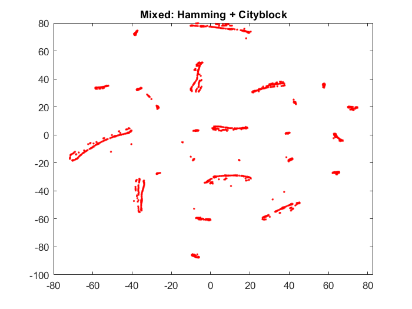

```matlab
rng('default') % for fair comparison 9 cl
Y = tsne(X,'Algorithm','exact','Distance', @MixDistanceL2);
gscatter(Y(:,1),Y(:,2))
title('Mixed: Hamming + Cityblock')
```

Now, Let's scale up and try a 3-D t-SNE embedding.

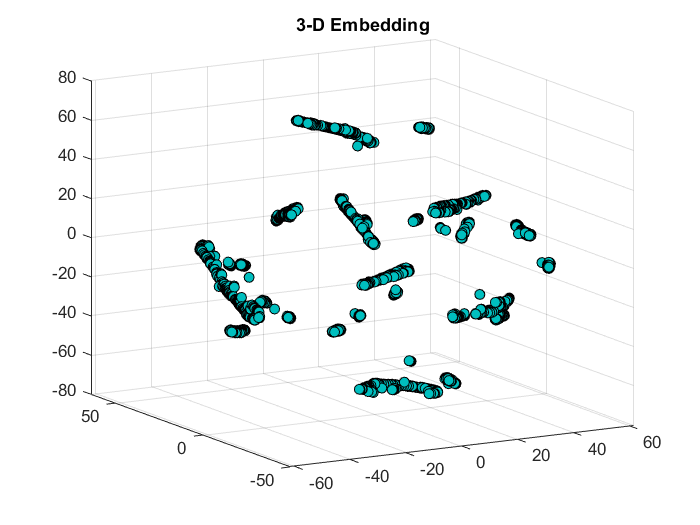

```matlab
rng('default') % for fair comparison
Y = tsne(X,'Algorithm','exact','Distance', @MixDistanceL1,'NumDimensions',3);
figure
scatter3(Y(:,1),Y(:,2),Y(:,3),...
        'MarkerEdgeColor','k',...
        'MarkerFaceColor',[0 .75 .75])
title('3-D Embedding')
view(-30,15)
```

#### Similarity/dissimilarity matrix

We find the similarity between every pair of objects in the data set using the two custom distance metrics.

```matlab
D1 = pdist(X, @MixDistanceL1);   %calculate the distance between every pair of objects in the dataset using MixDistanceL1
D2 = pdist(X, @MixDistanceL2); %calculate the distance between every pair of objects in the dataset using MixDistanceL2
```

#### Linkages

In this step we group the objects into a binary, hierarchical cluster tree. We link pairs of objects that are in close proximity using the [linkage](https://it.mathworks.com/help/stats/linkage.html) function. The linkage function uses the distance information generated in previous step to determine the proximity of objects to each other. As objects are paired into binary clusters, the newly formed clusters are grouped into larger clusters until a hierarchical tree is formed.

In the output of the linkage function , each row identifies a link between objects or clusters. The first two columns identify the objects that have been linked. The third column contains the distance between these objects.

We tried all the linkages that were not appropriate for Euclidean distances only.

```matlab
%linkages using the L1 mix distance
single1 = linkage(D1, "single");
complete1 = linkage(D1, "complete");
average1 = linkage(D1, "average");
weighted1 = linkage(D1, "weighted");

%linkages using the L2 mix distance
single2 = linkage(D2, "single");
complete2 = linkage(D2, "complete");
average2 = linkage(D2, "average");
weighted2 = linkage(D2, "weighted");
```

#### Cluster tree evaluation: Verify Dissimilarity

In a hierarchical cluster tree, any two objects in the original data set are eventually linked together at some level. The height of the link represents the distance between the two clusters that contain those two objects. This height is known as the cophenetic distance between the two objects. One way to measure how well the cluster tree generated by the linkage function reflects your data is to compare the cophenetic distances with the original distance data generated by the pdist function. If the clustering is valid, the linking of objects in the cluster tree should have a strong correlation with the distances between objects in the distance vector. The cophenet function compares these two sets of values and computes their correlation, returning a value called the cophenetic correlation coefficient. The closer the value of the cophenetic correlation coefficient is to 1, the more accurately the clustering solution reflects your data.

```matlab
c_single1 = cophenet(single1,D1)
```

c_single1 = 0.5125

```matlab
c_single2 = cophenet(single2,D2)
```

c_single2 = 0.6844

```matlab
c_average1 = cophenet(average1,D1)
```

c_average1 = 0.7100

```matlab
c_average2 = cophenet(average2,D2)
```

c_average2 = 0.8136

```matlab
c_complete1 = cophenet(complete1,D1)
```

c_complete1 = 0.6111

```matlab
c_complete2 = cophenet(complete2,D2)
```

c_complete2 = 0.7359

```matlab
c_weighted1 = cophenet(weighted1,D1)
```

c_weighted1 = 0.6298

```matlab
c_weighted2 = cophenet(weighted2,D2)
```

c_weighted2 = 0.7751

## Choosing the linkage and the dissimilarity measure

```matlab
% Complete Dataset used for clustering
X = [XCat XNum];

% Dataset with the original variables used for cluster inspection
dati = Data;
```

Compute the new similarity matrix and the hierarchical cluster tree

```matlab
D2 = pdist(X, @MixDistanceL2);
complete2 = linkage(D2, "complete");
```

#### Dendrograms

The hierarchical binary cluster tree created by the linkage function is most easily understood when viewed graphically. The function dendogram plots the tree as follows.

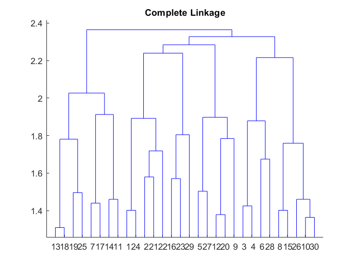

```matlab
figure
dendrogram(complete2)
title("Complete Linkage")
```

By a quick look at the denfrogram the best heigth to cut the cluster tree seems to be that which generate 6 clusters.

## Creation of the Clusters

We create a different number of clusters by cutting the dedrogram at different heigth, this is done to see if the internal clustering validation measures, such as the Calinski-Harabasz index and the Davies-Bouldin index, also suggest that 6 is a sensible number of clusters.

5 clusters

```matlab
T5 = cluster(complete2,'maxclust',5);
```

6 clusters

```matlab
T6 = cluster(complete2,'maxclust',6);
```

7 clusters

```matlab
T7 = cluster(complete2,'maxclust',7);
```

8 clusters

```matlab
T8 = cluster(complete2,'maxclust',8);
```

9 clusters

```matlab
T9 = cluster(complete2,'maxclust',9);
```

#### Clustering evaluation

Our goal is to determine how well the data fits into a particular number of clusters using different evaluation criteria.

Calinski-Harabasz criterion

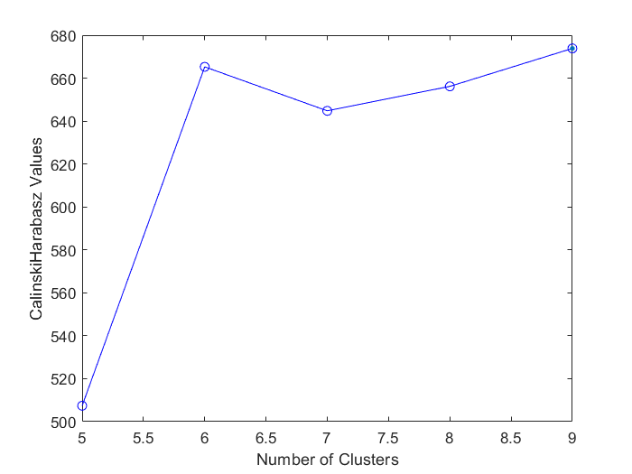

```matlab
clust = [T5 T6 T7 T8 T9];
eva1 = evalclusters(X,clust,'CalinskiHarabasz');
figure
plot(eva1)
```

```matlab
eva1
```

eva1 =

CalinskiHarabaszEvaluation with properties: NumObservations: 5000 InspectedK: [5 6 7 8 9] CriterionValues: [507.4012 665.2707 644.7739 656.1776 673.8510] OptimalK: 9

The score is higher when clusters are dense and well separated, which relates to a standard concept of a cluster. The plot shows that the highest Calinski-Harabasz values occurs at 6 and 9 clusters, suggesting that 6 seems to be an optimal number of clusters.

Davies-Bouldin criterion

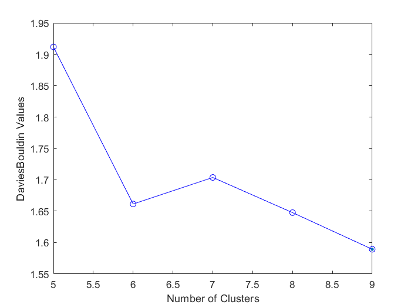

```matlab
eva2 = evalclusters(X,clust,'DaviesBouldin');
figure
plot(eva2)
```

```matlab
eva2
```

eva2 =

DaviesBouldinEvaluation with properties: NumObservations: 5000 InspectedK: [5 6 7 8 9] CriterionValues: [1.9117 1.6614 1.7037 1.6477 1.5894] OptimalK: 9

A lower Davies-Bouldin index relates to a model with better separation between the clusters. The plot shows that the lowest Davies-Bouldin values occurs at 6,8,9 clusters, confirming the previous hypothesis.

Silhouette criterion

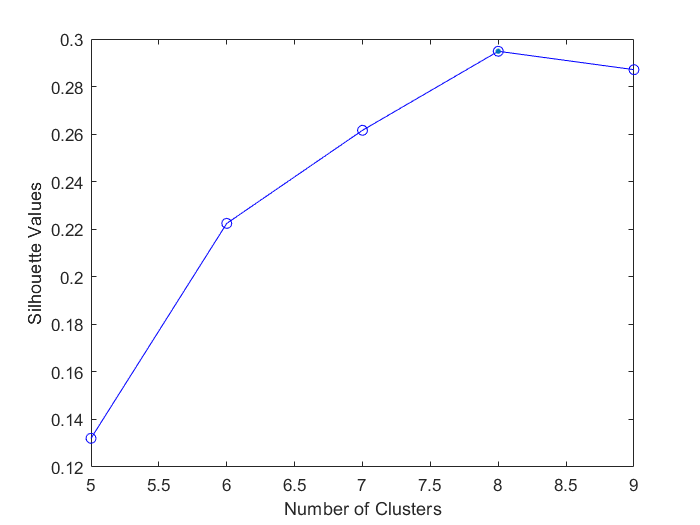

```matlab
eva3 = evalclusters(X,clust,'silhouette');
figure
plot(eva3)
```

```matlab
eva3
```

eva3 =

SilhouetteEvaluation with properties: NumObservations: 5000 InspectedK: [5 6 7 8 9] CriterionValues: [0.1321 0.2224 0.2616 0.2948 0.2871] OptimalK: 8

Although the silhoutte index does not confirm 6 as the optimal number of clusters, a later inspection of the 7-th and 8-th partition suggests the use of 6 clusters according to the two previous indices.

## Cluster inspection

#### Clusters composition

```matlab
tabulate(T6)
```

Value Count Percent 1 974 19.48% 2 1554 31.08% 3 147 2.94% 4 435 8.70% 5 687 13.74% 6 1203 24.06%

This is the code used for the cluster inspection. For categorical features we used frequency tables and for numerical features we used the summary statistics as the mean and the empirical distribution.

```matlab
% Select the number of the cluster
Z = dati(T6==1,:);
```

#### Categorical features

```matlab
% Frequency tables
tabulate(Z.Job)
tabulate(Z.Area)
tabulate(Z.CitySize)
tabulate(Z.Investments)
```

#### Age

```matlab
summary(Z(:,"Age"))
histogram(Z.Age)
mean(Z.Age)
```

#### Income

```matlab
summary(Z(:, "Income"))
histogram(Z.Income)
mean(Z.Income)
```

#### Wealth

```matlab
summary(Z(:, "Wealth"))
histogram(Z.Wealth)
mean(Z.Wealth)
```

#### Debt

```matlab
summary(Z(:, "Debt"))
histogram(Z.Debt)
mean(Z.Debt)
```

#### Financial Education

```matlab
summary(Z(:, "FinEdu"))
histogram(Z.FinEdu)
mean(Z.FinEdu)
```

#### ESG

```matlab
summary(Z(:, "ESG"))
histogram(Z.ESG)
mean(Z.ESG)
```

#### Digital

```matlab
summary(Z(:, "Digital"))
histogram(Z.Digital)
mean(Z.Digital)
```

#### BankFriend

```matlab
summary(Z(:, "BankFriend"))
histogram(Z.BankFriend)
mean(Z.BankFriend)
```

#### LifeStyle

```matlab
summary(Z(:, "LifeStyle"))
histogram(Z.LifeStyle)
mean(Z.LifeStyle)
```

#### Luxury

```matlab
summary(Z(:, "Luxury"))
histogram(Z.Luxury)
mean(Z.Luxury)
```

#### Saving

```matlab
summary(Z(:, "Saving"))
histogram(Z.Saving)
mean(Z.Saving)
```

#### Example with the first cluster

```matlab
% Select the number of the cluster
Z = dati(T6==1,:);
```

#### Categorical features

```matlab
% Frequency tables
tabulate(Z.Job)
```

Value Count Percent 1 105 10.78% 2 653 67.04% 3 10 1.03% 4 12 1.23% 5 194 19.92%

```matlab
tabulate(Z.Area)
```

Value Count Percent 1 824 84.60% 2 0 0.00% 3 150 15.40%

```matlab
tabulate(Z.CitySize)
```

Value Count Percent 1 974 100.00% 2 0 0.00% 3 0 0.00%

```matlab
tabulate(Z.Investments)
```

Value Count Percent 1 0 0.00% 2 386 39.63% 3 588 60.37%

#### Age

```matlab
summary(Z(:,"Age"))
```

Variables: **Age**: 974×1 double Values: Min 19 Median 68 Max 95

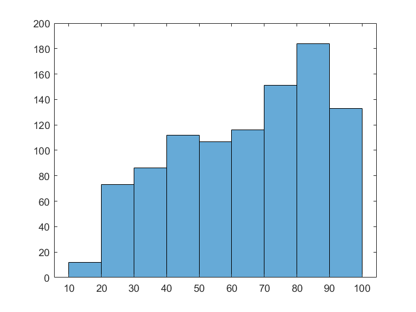

```matlab
histogram(Z.Age)
```

```matlab
mean(Z.Age)
```

ans = 64.2906

#### Income

```matlab
summary(Z(:, "Income"))
```

Variables: **Income**: 974×1 double Values: Min 0.016642 Median 0.53899 Max 0.97972

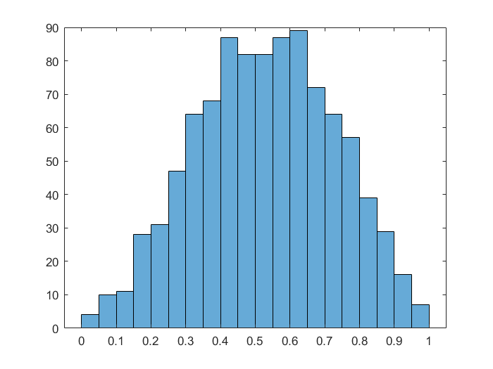

```matlab
histogram(Z.Income)
```

```matlab
mean(Z.Income)
```

ans = 0.5309

#### Wealth

```matlab
summary(Z(:, "Wealth"))
```

Variables: **Wealth**: 974×1 double Values: Min 0.037519 Median 0.55942 Max 0.98115

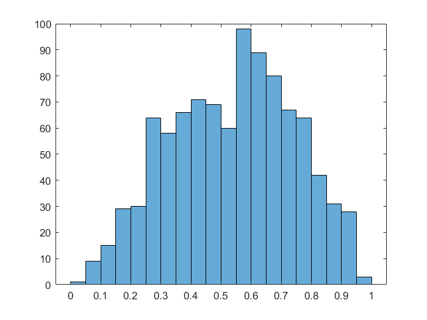

```matlab
histogram(Z.Wealth)
```

```matlab
mean(Z.Wealth)
```

ans = 0.5387

#### Debt

```matlab
summary(Z(:, "Debt"))
```

Variables: **Debt**: 974×1 double Values: Min 0 Median 0.43395 Max 0.95504

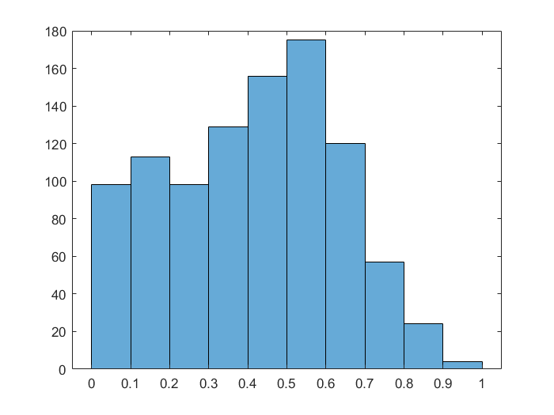

```matlab
histogram(Z.Debt)
```

```matlab
mean(Z.Debt)
```

ans = 0.4139

#### Financial Education

```matlab
summary(Z(:, "FinEdu"))
```

Variables: **FinEdu**: 974×1 double Values: Min 0.047841 Median 0.45868 Max 0.91725

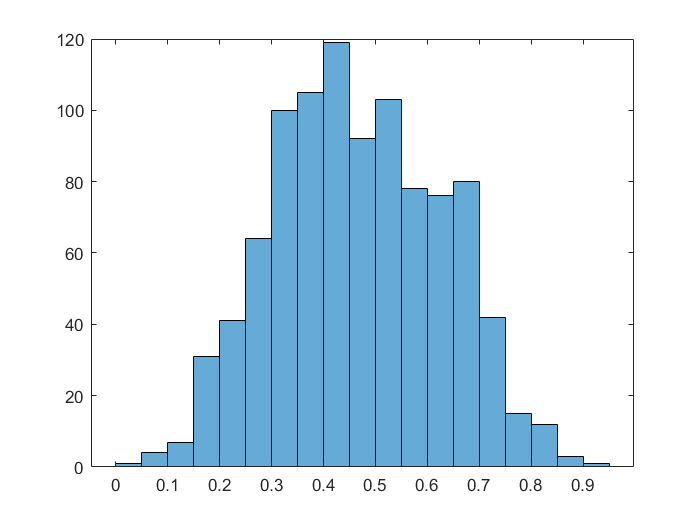

```matlab
histogram(Z.FinEdu)
```

```matlab
mean(Z.FinEdu)
```

ans = 0.4674

#### ESG

```matlab
summary(Z(:, "ESG"))
```

Variables: **ESG**: 974×1 double Values: Min 0.1568 Median 0.56872 Max 0.93987

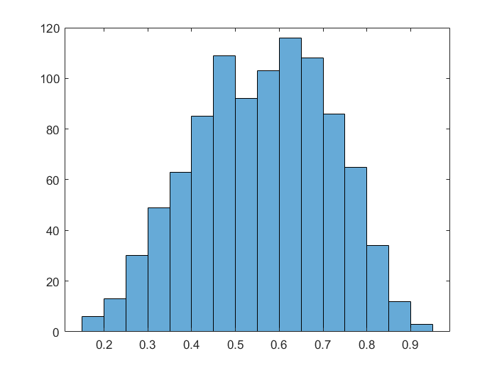

```matlab
histogram(Z.ESG)
```

```matlab
mean(Z.ESG)
```

ans = 0.5612

#### Digital

```matlab
summary(Z(:, "Digital"))
```

Variables: **Digital**: 974×1 double Values: Min 0.0047112 Median 0.46399 Max 0.93089

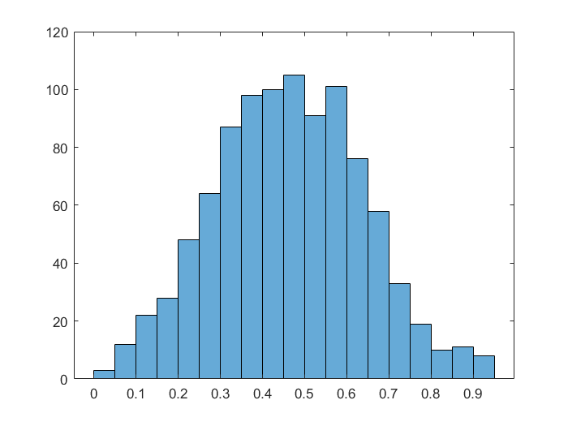

```matlab
histogram(Z.Digital)
```

```matlab
mean(Z.Digital)
```

ans = 0.4630

#### BankFriend

```matlab
summary(Z(:, "BankFriend"))
```

Variables: **BankFriend**: 974×1 double Values: Min 0.13104 Median 0.59875 Max 0.95548

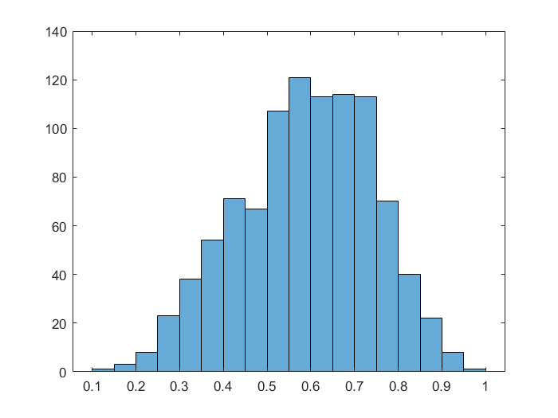

```matlab
histogram(Z.BankFriend)
```

```matlab
mean(Z.BankFriend)
```

ans = 0.5885

#### LifeStyle

```matlab
summary(Z(:, "LifeStyle"))
```

Variables: **LifeStyle**: 974×1 double Values: Min 0 Median 0.36285 Max 0.97683

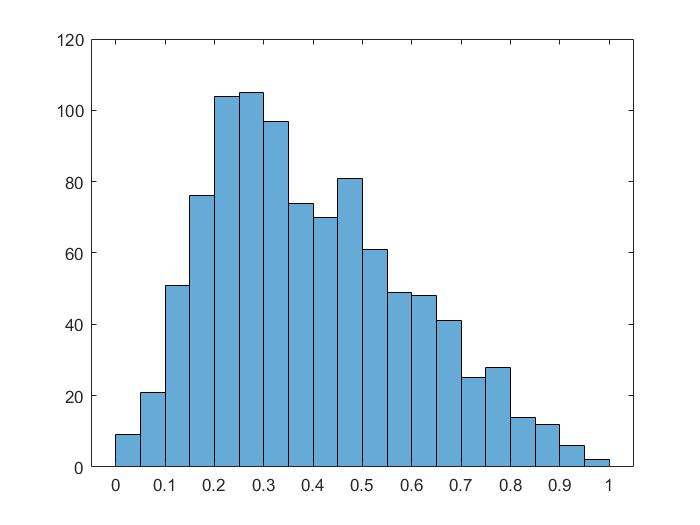

```matlab
histogram(Z.LifeStyle)
```

```matlab
mean(Z.LifeStyle)
```

ans = 0.3982

#### Luxury

```matlab
summary(Z(:, "Luxury"))
```

Variables: **Luxury**: 974×1 double Values: Min 0 Median 0.3672 Max 0.96898

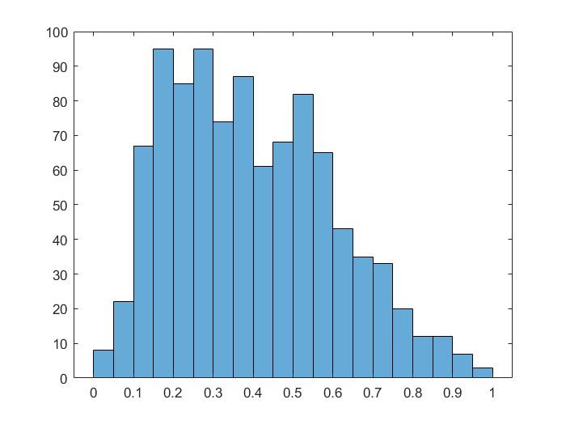

```matlab
histogram(Z.Luxury)
```

```matlab
mean(Z.Luxury)
```

ans = 0.3972

#### Saving

```matlab
summary(Z(:, "Saving"))
```

Variables: **Saving**: 974×1 double Values: Min 0.004191 Median 0.53001 Max 0.93818

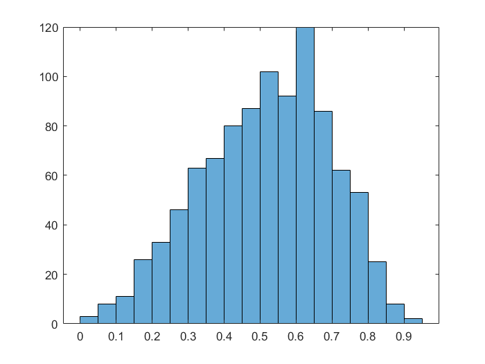

```matlab
histogram(Z.Saving)
```

```matlab
mean(Z.Saving)
```

ans = 0.5164

# Issues

The main problem we encountered concerns the scalability of the hierarchical clustering algorithm: in fact, during the exploration of the best linkages and distances using a subsample, after identifying a method that gave good results in terms of indeces, the transition to the complete dataset changed the results completely. Therefore by changing the number of observations to cluster, the optimal number of clusters change and also the composition of the clusters varies considerably. This high variability of the results based on the dataset size seems to suggest that the hierarchical clustering algorithm does not work well with large datasets.

Other possible issues/doubts concern the arbitrary decisions we made:

- both in the choice of distance metric and in the choice of linkage criteria we used the cophenetic coefficient. According to this coefficent the distance metric and the linkage we used are not the best choice, but after some results analysis we found out that they perform better than the ones suggested by the coefficient. Therefore our choice was in some sense arbitrary.
- subsequently we analyzed the best number of clusters using the dendrogram and some internal clustering validation measures, and in the end we inspected the clusters to obtain the best partition in terms of business interpretability, but we did not find out strong discrimination between the groups, as one could have expected at the beginning, indeed the identification of the personas was difficult.

In conclusion there isn't any strong theoretical basis for such decisions, but we based them on several guesses and attempts and this makes the results of dubious significance.